# Отчёт по лабораторной работе №10

Расширенные настройки SMTP-сервера (Postfix + Dovecot)

Элсаиед Адел

Российский университет дружбы народов, Москва, Россия

4 января 2026

# Цели и задачи работы

## Цель лабораторной работы

Приобретение практических навыков конфигурирования SMTP-сервера в части настройки аутентификации и защищённой отправки почты.

# Выполнение работы

## LMTP: включение протокола в Dovecot

В файле `/etc/dovecot/dovecot.conf` расширен список протоколов: добавлен LMTP, что позволяет Dovecot принимать почту от Postfix через локальный протокол доставки.

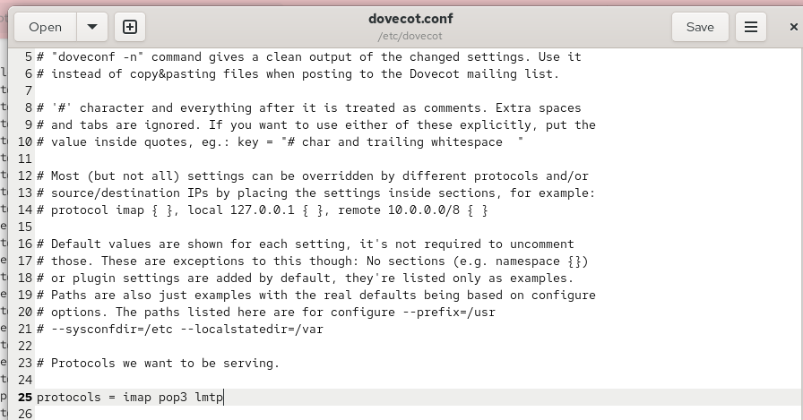

Добавление LMTP в список протоколов

## LMTP: сокет для связи Postfix ↔︎ Dovecot

В `/etc/dovecot/conf.d/10-master.conf` настроен сервис `lmtp` и UNIX-сокет `/var/spool/postfix/private/dovecot-lmtp` с правами доступа и принадлежностью `postfix:postfix`, чтобы Postfix мог безопасно передавать сообщения Dovecot.

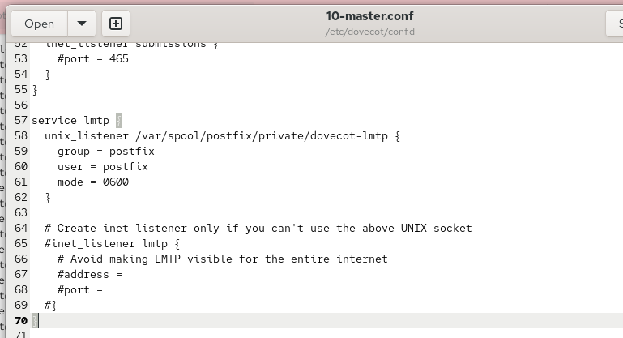

Настройка сервиса lmtp и UNIX-сокета

## Dovecot: формат логина для аутентификации

В `/etc/dovecot/conf.d/10-auth.conf` установлен формат имени пользователя `auth_username_format = %Ln`, чтобы аутентификация выполнялась по логину без доменной части и с приведением к нижнему регистру.

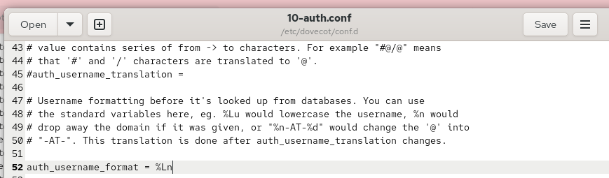

Настройка auth_username_format

## Проверка LMTP: доставка и журналы

При отправке тестового сообщения на стороне сервера в `/var/log/maillog` наблюдаются стадии: SMTP-сеанс → постановка в очередь → передача в транспорт `lmtp` → приём Dovecot → сохранение в INBOX.

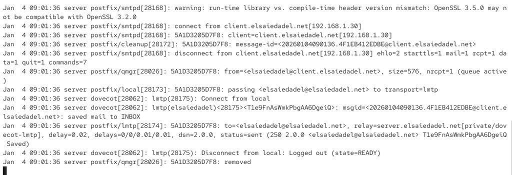

Фрагмент maillog при доставке через LMTP

## Проверка Maildir

На сервере выполнена проверка почтового ящика формата Maildir: тестовое письмо «LMTP test» присутствует во входящих.

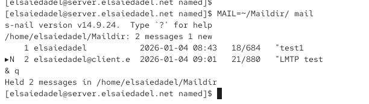

Проверка почтового ящика пользователя

## SMTP AUTH: настройка службы auth в Dovecot

В `/etc/dovecot/conf.d/10-master.conf` определена служба `auth`: - сокет `/var/spool/postfix/private/auth` для Postfix (права `0660`, владелец/группа postfix); - сокет `auth-userdb` для внутренних операций Dovecot (права `0600`, пользователь dovecot).

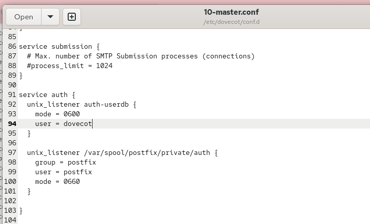

Конфигурация service auth

## SMTP AUTH: параметры Postfix

В Postfix включена SASL-аутентификация через Dovecot: задан тип `dovecot` и путь `private/auth`. Дополнительно настроены ограничения получателей для защиты от несанкционированного relay.

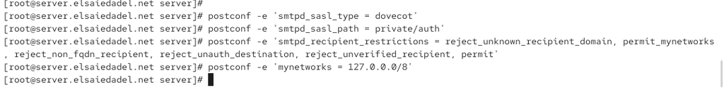

Настройка SASL и ограничений через postconf

## SMTP AUTH: временная проверка на 25 порту

Для тестирования авторизации в `/etc/postfix/master.cf` временно включены параметры `smtpd_sasl_auth_enable` и упрощённые ограничения, разрешающие доставку при успешной аутентификации.

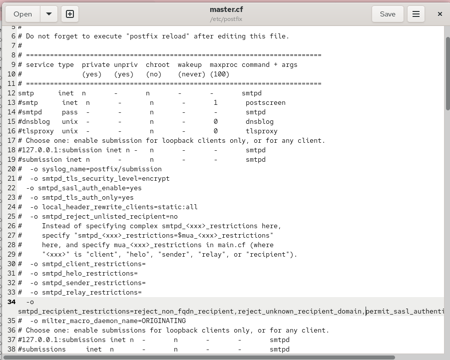

Изменение master.cf для теста SMTP AUTH

## SMTP AUTH: тестирование с клиента

На клиенте выполнена проверка: получена base64-строка для `AUTH PLAIN`, выполнено подключение и успешная аутентификация пользователя.

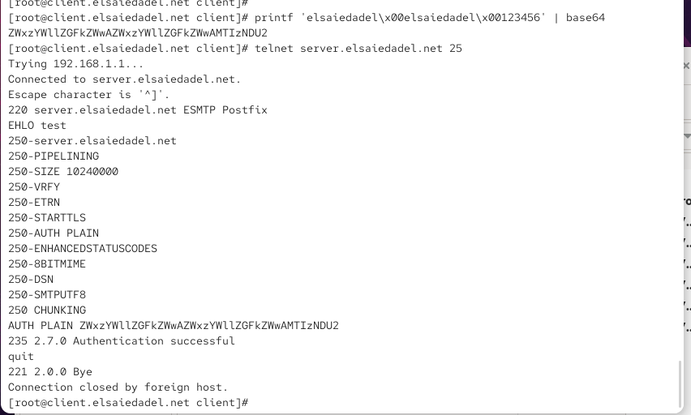

Проверка AUTH PLAIN с клиента

## SMTP over TLS: подготовка сертификата и параметры Postfix

Использован временный сертификат Dovecot: сертификат и ключ перенесены в `/etc/pki/tls/…` для корректной работы с SELinux. В Postfix заданы пути к сертификату/ключу, кэш TLS-сессий и уровень `may`.

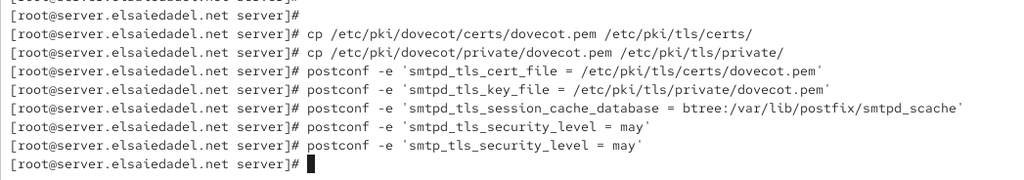

Копирование сертификата и настройка TLS в Postfix

## SMTP over TLS: служба submission (587)

В `/etc/postfix/master.cf` настроена служба `submission` на порту 587: - обязательное шифрование `smtpd_tls_security_level=encrypt`; - включена SMTP-аутентификация; - ограничения для получателей как при тестировании AUTH.

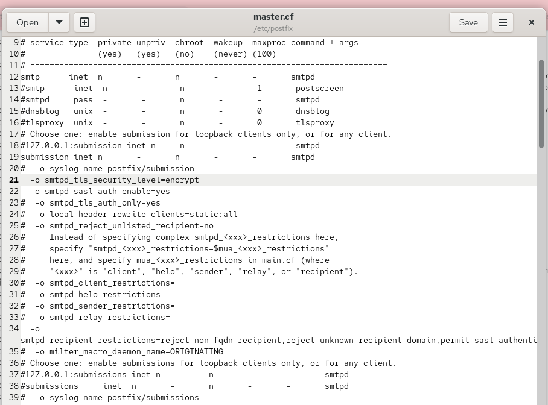

Настройка submission в master.cf

## Проверка STARTTLS на 587 порту

С клиента выполнено подключение к 587 порту с STARTTLS, подтверждена поддержка `AUTH PLAIN` и успешная аутентификация по защищённому каналу.

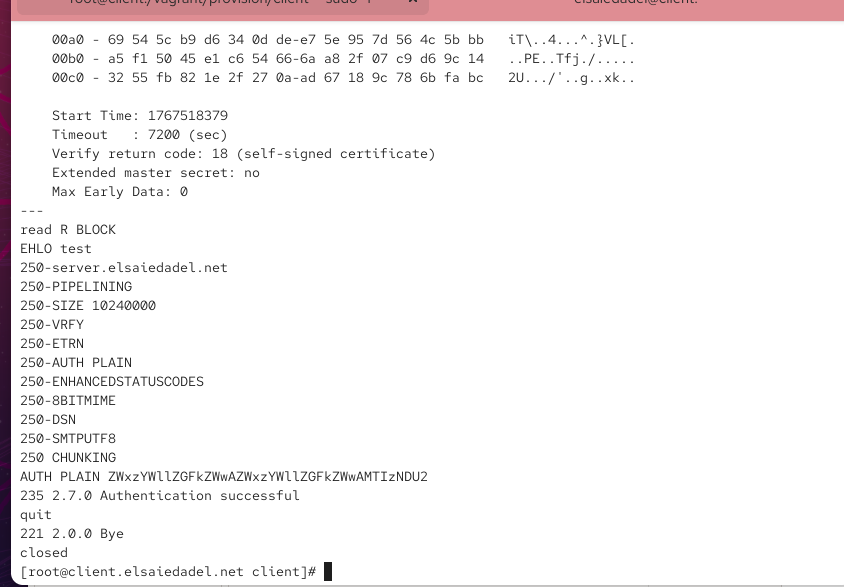

Проверка STARTTLS и AUTH на 587 порту

## Отправка почты через Evolution

Проверка пользовательского сценария выполнена через Evolution: SMTP-сервер настроен на порт 587, STARTTLS и обычный пароль. Письма успешно отправлены и доставлены.

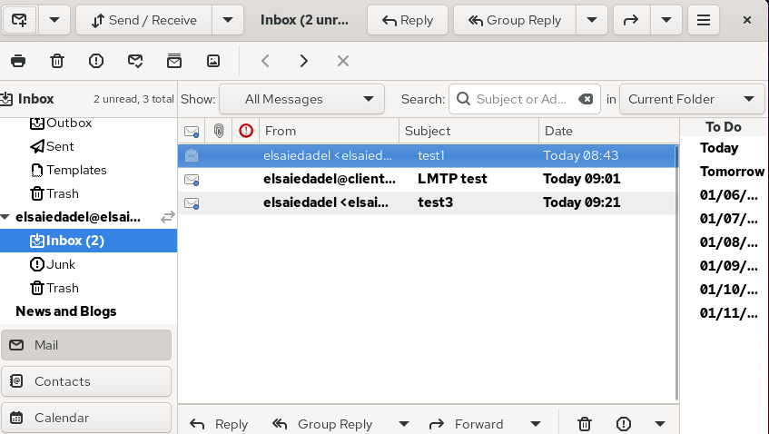

Проверка отправки через Evolution

## Подтверждение по журналам

В `/var/log/maillog` отражены этапы: подключение клиента → TLS → SASL-аутентификация → передача в LMTP → сохранение в INBOX.

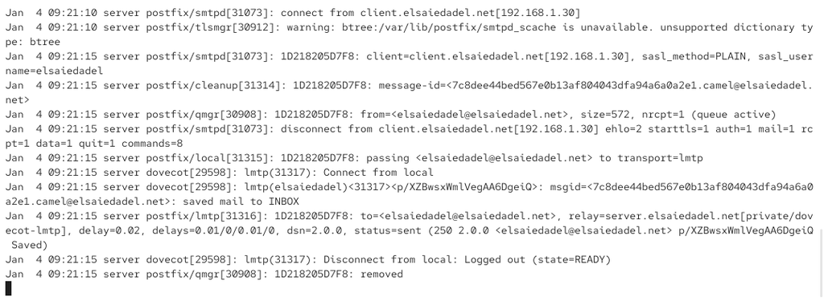

Журнал доставки при SMTP over TLS

## Интеграция в provisioning: перенос конфигов

Актуальные конфигурационные файлы Dovecot и Postfix скопированы в каталог `/vagrant/provision/server/...` для воспроизводимого развёртывания.

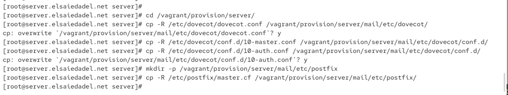

Копирование конфигов в provision-дерево

## Интеграция в provisioning: server/mail.sh

В скрипт добавлены шаги установки пакетов, копирования конфигурации, настройки firewall, а также параметры Postfix для LMTP, SMTP AUTH и SMTP over TLS.

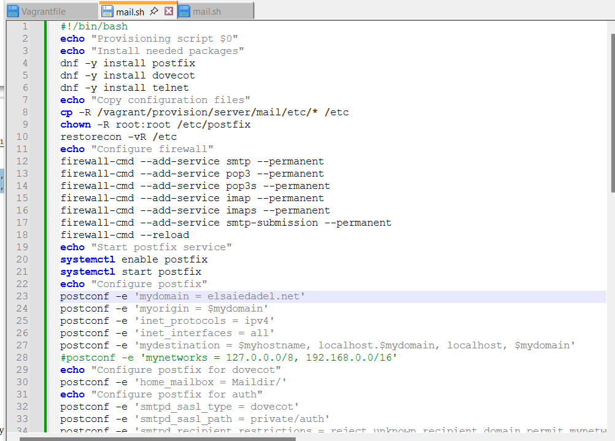

Изменения в /vagrant/provision/server/mail.sh

## Интеграция в provisioning: client/mail.sh

В provisioning-скрипт клиента добавлена установка утилиты telnet для диагностики SMTP-сеансов и проверки аутентификации.

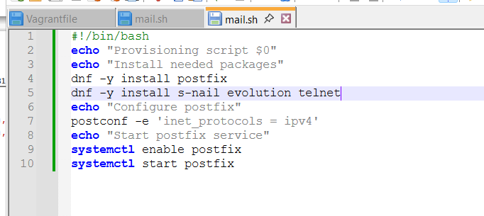

Изменения в /vagrant/provision/client/mail.sh

# Выводы

## Вывод

В ходе лабораторной работы настроены расширенные функции почтового сервера: доставка по LMTP, SMTP-аутентификация через Dovecot и защищённая отправка по SMTP over TLS (submission/587, STARTTLS). Работоспособность подтверждена тестами с клиента (AUTH и STARTTLS), а также анализом журналов. Конфигурации и действия интегрированы в provisioning-скрипты Vagrant, что обеспечивает воспроизводимость стенда.